# graphsim: directed plots for igraph objects

S. Thomas Kelly<sup>1,2</sup>, Michael A. Black<sup>1</sup> <sup>1</sup> Department of Biochemistry, University of Otago, PO Box 56, Dunedin 9054, New Zealand <sup>2</sup> RIKEN Center for Integrative Medical Sciences, Suehiro-cho-1-7-22, Tsurumi Ward, Yokohama

Thursday 29 July 2021

**Summary**

Guide on how to plot directed graphs from `igraph` objects to display activating and repressive states.

**Package**

graphsim 1.0.0

# 1 Directed graph plots

## 1.1 Motivations

Here we demonstrate the plotting functions that come built-in with `graphsim`, an alternative to the `plot.igraph` provided by the `igraph` package. Here we provide additional functionality for plotting directed graphs. This draws upon many functions provided by `igraph`, including layout settings (Csardi and Nepusz 2006).

In particular, graph and network representations in biology often require displaying edge properties (Barabási and Oltvai 2004). Here we have the “state” parameter which can be used to differentiate these, and allow us to represent activating and inhibiting or repressing relationships differently. We use different arrowheads as per convention in molecular biology.

## 1.2 Getting started

To generate these plots, the following packages must be imported.

```r
library("igraph")
library("scales")
library("graphsim")
```

# 2 Toy example

Here we demonstrate the plot functions on a small toy graph.

## 2.1 Set up simulated graph

First we generate a graph object using the `igraph` package.

```r
graph_edges <- rbind(c("A", "C"), c("B", "C"), c("C", "D"), c("D", "E"),
                     c("D", "F"), c("F", "G"), c("F", "I"), c("H", "I"))
graph <- graph.edgelist(graph_edges, directed = TRUE)
```

## 2.2 Plotting

We next demonstrate the plotting function for directed graph objects. `plot_directed` with default settings uses the `layout.fruchterman.reingold` as does built-in plotting function `igraph::plot.igraph`. This function provides additional functionality to displaying directed graphs in particular.

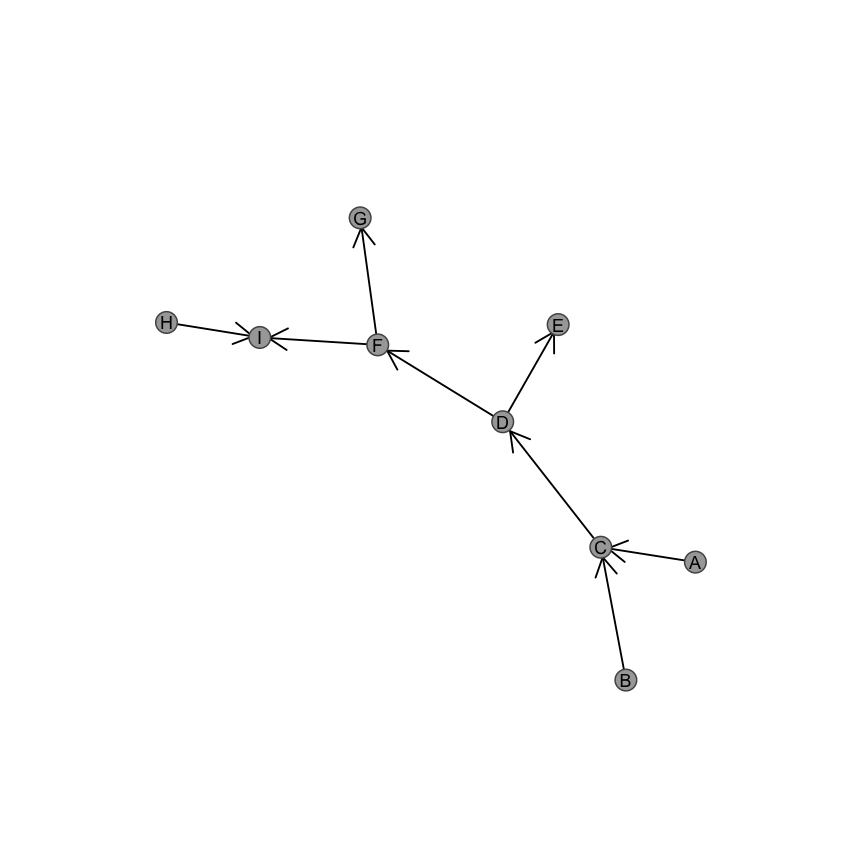

```r
plot_directed(graph)
```

Here you can see that the plotting function displays a graph in a similar layout to `plot.igraph` with different aesthetic parameters. We suggest that you choose the function that suits your needs and datasets. We demonstrate the features available for `plot_directed` below.

### 2.2.1 Custom aesthetics

We support various aesthetic parameters to control the colour and relative size of nodes and edges.

`plot_directed` supports customised layouts:

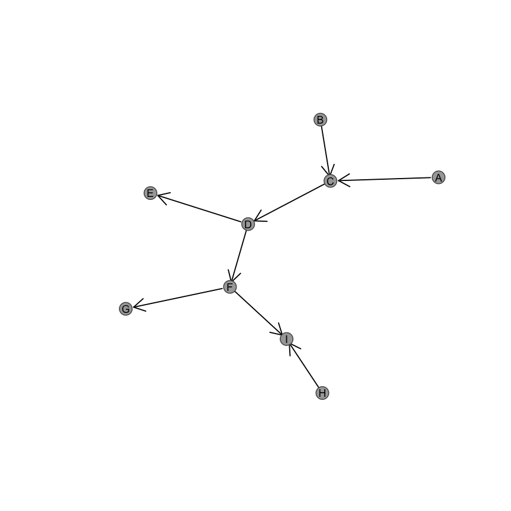

```r
plot_directed(graph, layout = layout.kamada.kawai)
```

In addition, custom colouts are supported:

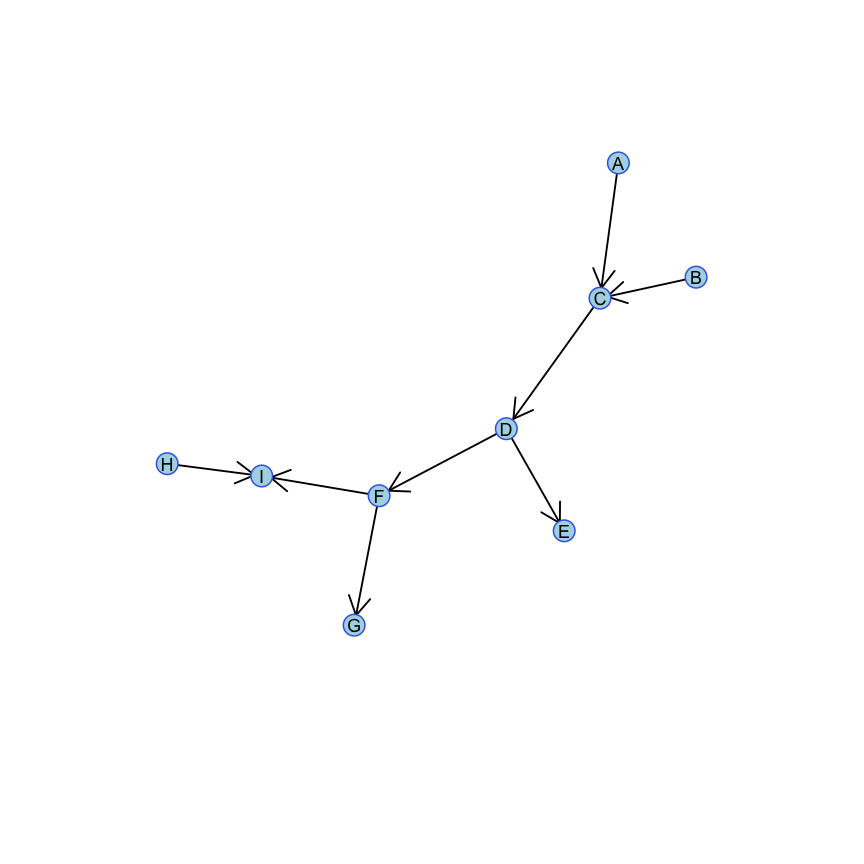

```r
plot_directed(graph, fill.node = "lightblue", border.node = "royalblue")
```

#### 2.2.1.1 Vectorisation of aesthetics

Colours may also be entered as a vector for each node in `V(graph)`:

```r
names(V(graph))
```

```
## [1] "A" "C" "B" "D" "E" "F" "G" "I" "H"
```

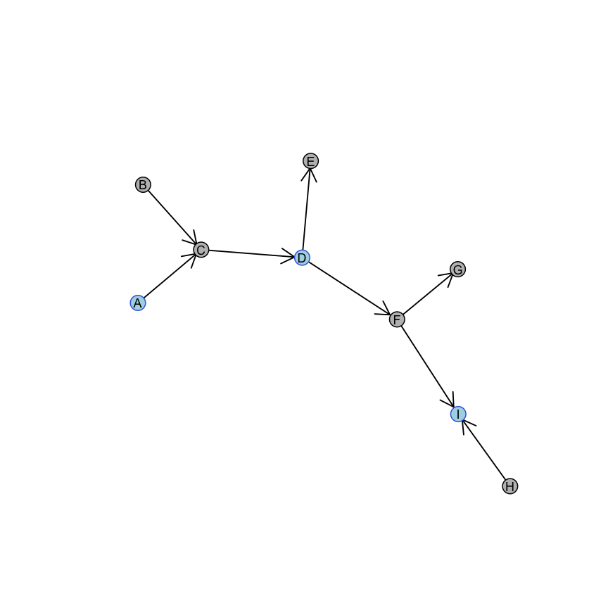

```r
colour_vector <- ifelse(names(V(graph)) %in% c("A", "D", "I"), 1, 2)
plot_directed(graph, fill.node = c("lightblue", "grey")[colour_vector], border.node = c("royalblue", "black")[colour_vector])
```

This functionality allows highlighting of particular groups based on known properties of the graph. For examples `V(graph)$type` for bipartite graphs or partitions from Louvain (`igraph::cluster_louvain`) or Leiden (`leiden::leiden`) clustering algorithms.

### 2.2.2 Arrow customisation

The `state` parameter controls whether the links are “activating” or “inhibiting”. These can denote activation and repression: foe example, positive and negative regulation of genes or kinase and phosphatase activity of proteins. These may be specified globally as either a character string or numeric:

Activating links are displated with any of the following:

- “activating”
- `1`
- `0`

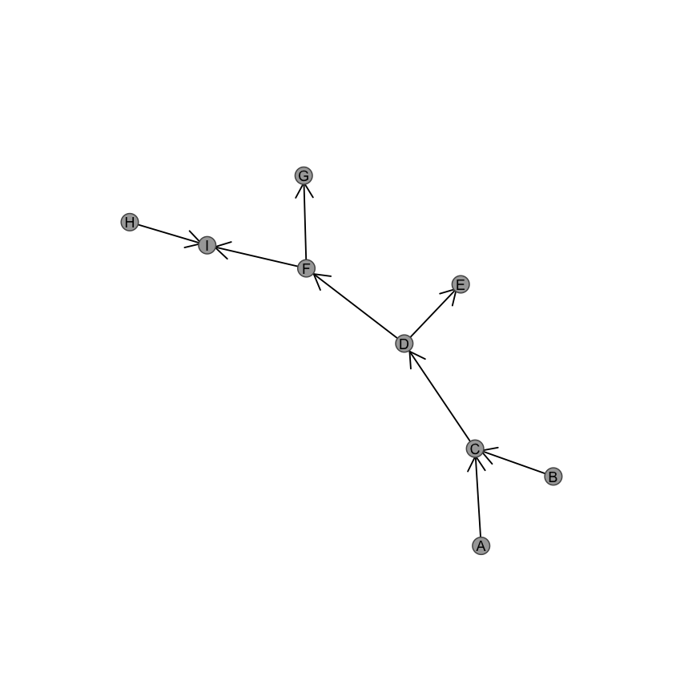

```r
plot_directed(graph, state = "activating")
```

Note that activating states can also be specified as follows:

```r
plot_directed(graph, state = 1)
plot_directed(graph, state = 0)
```

Inhibiting links are displated with any of the following:

- “inhibiting”
- `-1`
- `2`

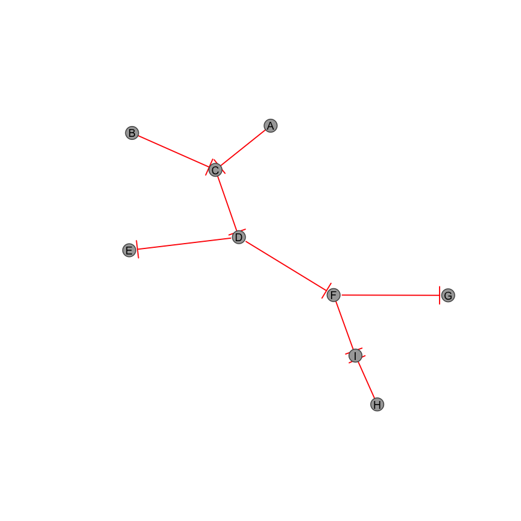

```r
plot_directed(graph, state = "inhibiting")
```

Note that inhibiting states can also be specified as follows:

```r
plot_directed(graph, state = -1)
plot_directed(graph, state = 2)
```

#### 2.2.2.1 Vectorisation of edge properties

The state parameter may also be applied as a vector to each edge in `E(graph)` respectively.

```r
E(graph)
```

```
## + 8/8 edges from 952acd0 (vertex names):
## [1] A->C B->C C->D D->E D->F F->G F->I H->I
```

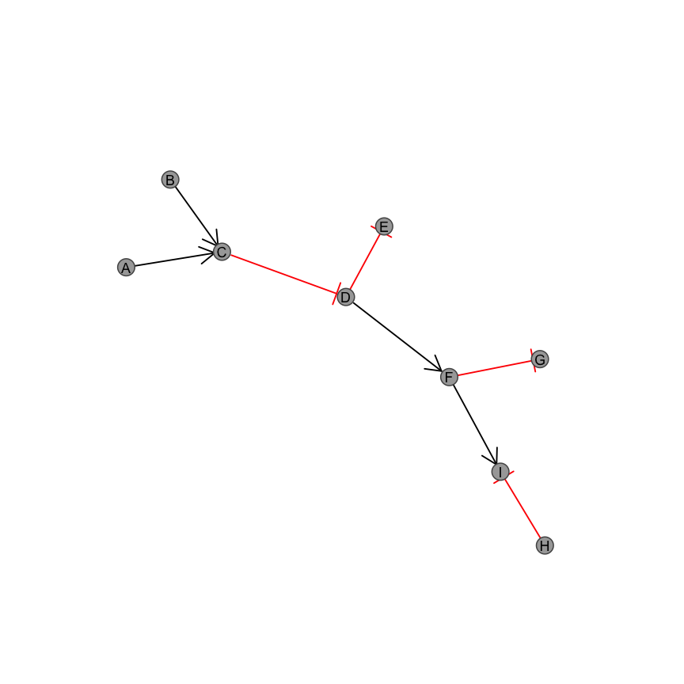

```r
plot_directed(graph, state = c(1, 1, -1, -1, 1, -1, 1, -1))
```

Note that by default, inhibiting relationships are highlighted with a different `col.arrow` value, which can be controlled by the input parameter.

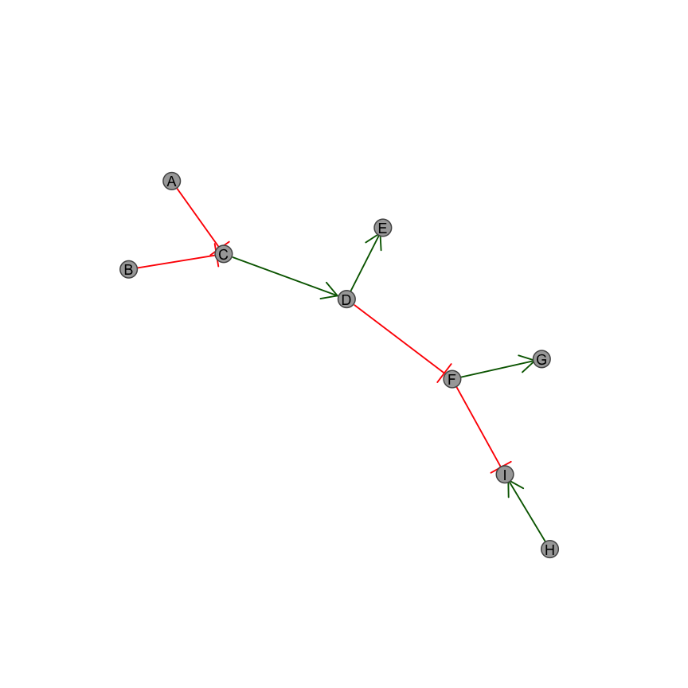

```r
edge_properties <- c(1, 1, -1, -1, 1, -1, 1, -1)/2 + 1.5
plot_directed(graph, state = edge_properties, col.arrow = c("darkgreen", "red")[edge_properties])
```

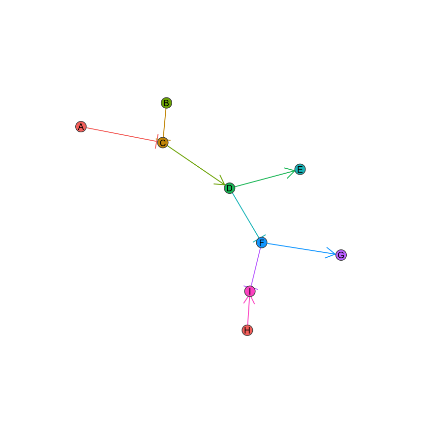

```r
edge_properties <- c(1, 1, -1, -1, 1, -1, 1, -1)/2 + 1.5
ggplot_colours <- c("#F8766D", "#CD9600", "#7CAE00", "#00BE67",
                    "#00BFC4", "#00A9FF", "#C77CFF", "#FF61CC")
plot_directed(graph, state = edge_properties,
              col.arrow = ggplot_colours, fill.node =  ggplot_colours)
```